{% raw %}

{% endraw %} {% raw %}

{% endraw %}

A sparse vector, as opposed to a dense one, is a vector which contains a lot of zeroes. When we speak about making a neural network sparse, we thus mean that the network's weight are mostly zeroes.

With fasterai, you can do that thanks to the `Sparsifier` class.

Let's start by creating a model

{% raw %}

```python
model = resnet18()
```

{% endraw %}

As you probably know, weights in a convolutional neural network have 4 dimensions ($ c_{out} \times c_{in} \times k_h \times k_w$)

{% raw %}

```python
model.conv1.weight.ndim
```

```
4
```

{% endraw %}

In the case of ResNet18, the dimension of the first layer weights is $64 \times 3 \times 7 \times 7$. We thus can plot each of the $64$ filter as a $7 \times 7$ color image (because they contains $3$ channels).

{% raw %}

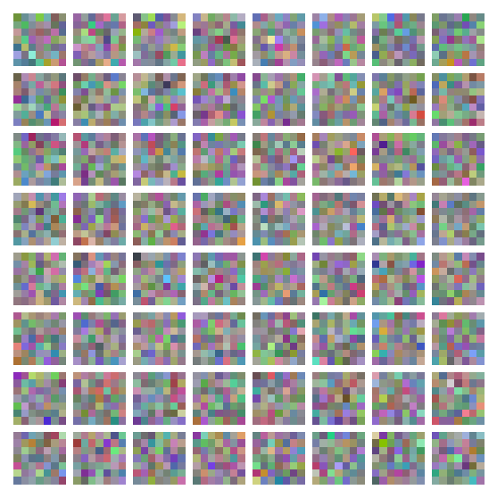

```python
plot_kernels(model.conv1)
```

{% endraw %} {% raw %}

`class` `Sparsifier`[[source]](https://github.com/nathanhubens/fasterai/tree/master/fasterai/sparse/sparsifier.py#L12)

> `Sparsifier`(**`model`**, **`granularity`**, **`method`**, **`criteria`**, **`layer_type`**=*`Conv2d`*)

{% endraw %} {% raw %}

{% endraw %}

The `Sparsifier` class allows us to remove some (part of) the filters, that are considered to be less useful than others. This can be done by first creating an instance of the class, specifying:

- The `granularity`, i.e. the part of filters that you want to remove. Typically, we usually remove weights, vectors, kernels or even complete filters.
- The `method`, i.e. if you want to consider each layer independently (`local`), or compare the parameters to remove across the whole network (`global`).
- The `criteria`, i.e. the way to assess the usefulness of a parameter. Common methods compare parameters using their magnitude, the lowest magnitude ones considered to be less useful.

User can pass a single layer to prune by using the `Sparsifier.prune_layer` method.

{% raw %}

`Sparsifier.prune_layer`[[source]](https://github.com/nathanhubens/fasterai/tree/master/fasterai/sparse/sparsifier.py#L18)

> `Sparsifier.prune_layer`(**`m`**, **`sparsity`**)

{% endraw %}

Most of the time, we may want to prune the whole model at once, using the `Sparsifier.prune_model` method, indicating the percentage of sparsity to you want to apply.

{% raw %}

`Sparsifier.prune_model`[[source]](https://github.com/nathanhubens/fasterai/tree/master/fasterai/sparse/sparsifier.py#L24)

> `Sparsifier.prune_model`(**`sparsity`**)

{% endraw %}

There are several ways in which we can make that first layer sparse. You will find the most important below:

## Pruning individual weights

As a reminder, the first convolutional layer of ResNet18 could be represented as a $64 \times 3 \times 7 \times 7$ tensor, meaning that the whole layer posess $9408$ weights.

When removing individual weights, we do not impose any constraint on where in the first layer the weight removed should come from. We only compare them all together and remove the ones that are the least important, according to our `criteria`. We thus remove $0d$ blocks from our $4d$ weight tensor.

Here is for example how you would proceed to remove $80 \%$ of the weights of the network.

{% raw %}

```python
model = resnet18()
pruner = Sparsifier(model, 'weight', 'local', large_final)
pruner.prune_layer(model.conv1, 80)
```

{% endraw %}

And here are what the first layer filters would look like.

{% raw %}

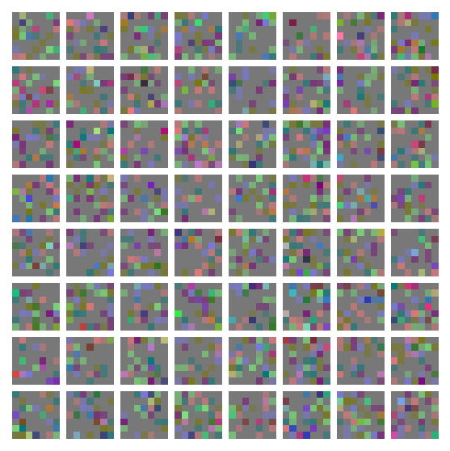

```python
plot_kernels(model.conv1)
```

{% endraw %}

## Pruning Vectors

When removing vectors, we don't compare $9408$ weights anymore as we now impose to remove complete vectors of weights from the first layer. We now remove $1d$ blocks from our layer and can chose to remove `column` vectors from the filters, but also `row` of `channel` vectors. In those cases, we thus compare respectively $64 \times 3 \times 7$ column vectors, or $64 \times 7 \times 3$ row vectors, or $64 \times 7 \times 7$ channel vectors, and remove the least important according to our criteria.

The consequence is that, we now start to see some structure emerging in our remaining weights.

{% include note.html content='If you look closely, you will see some red/green/blue vectors remaining. This means that we removed the 2 other vectors corresponding to the same spatial location but located at other color channel.' %}

{% raw %}

```python
model = resnet18()
pruner = Sparsifier(model, 'column', 'local', large_final)
pruner.prune_layer(model.conv1, 80)
```

{% endraw %} {% raw %}

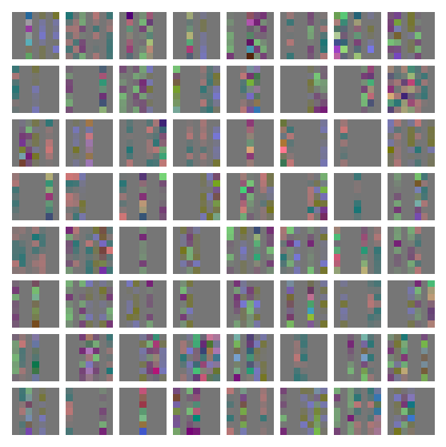

```python
plot_kernels(model.conv1)
```

{% endraw %}

A particular granularity to operate with is what we called `shared_weight`, which in this case consists of comparing $3 \times 7 \times 7$ blocks together. This results in an unstructured pruning scheme on a single filter, but this scheme is shared with all the other filters !

## Pruning Kernels

Having a network sparse kernel-wise means that we removed $2d$ blocks from our filter (generally from a spatial point of view). In our case, it means comparing each of the $64 \times 3$ kernels and removing the least important ones.

{% raw %}

```python
model = resnet18()
pruner = Sparsifier(model, 'kernel', 'local', large_final)
pruner.prune_layer(model.conv1, 80)
```

{% endraw %} {% raw %}

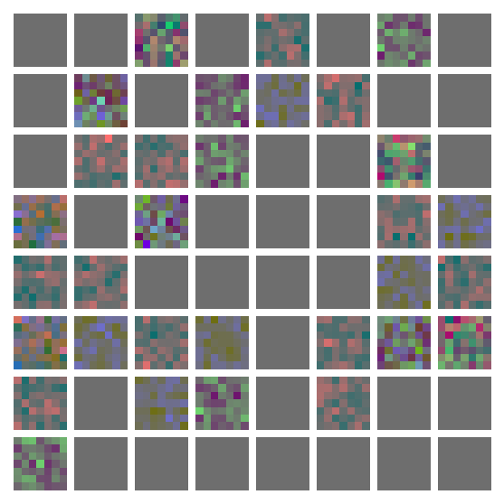

```python
plot_kernels(model.conv1)
```

{% endraw %}

## Pruning Filters

Finally, we can choose to remove entire filters. This means that now, we compare the $64$ filters together, thus removing $3d$ blocks.

{% raw %}

```python
model = resnet18()
pruner = Sparsifier(model, 'filter', 'local', large_final)
pruner.prune_layer(model.conv1, 80)
```

{% endraw %} {% raw %}

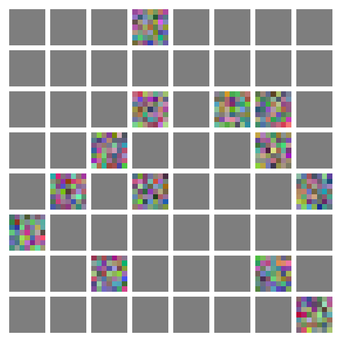

```python
plot_kernels(model.conv1)
```

{% endraw %}

For more information about granularities at which you can operate, please check the [related page](https://nathanhubens.github.io/fasterai/granularity.html).